# Investigation of Prescription Flows between General Practices and Boots Pharmacies via Spatial Interaction Modeling Techniques

Lenka Hasova

## **This a documentation of R code used for the dissertation research project for Boots company. Complete markdown availiable as copy and paste at [github/hasovalenka/masters](https://github.com/hasovalenka/masters/blob/master/Code_dissertation_markdown)**

It consists of 2 sections

1. Data processing
   - Loading data
   - Cleaning data
2. Modelling time
   - Modelling all the flows - full description in steps
   - Modeling other selections
   - Export the estimates from model
   - Final thoughts

**The models are coded in following order and names, therefore use ctr+f if you want to find a particular section**

[output not shown]

# Data processing

## Load the data and assighn projection

Here a note must be given to preprocessing through ArcGIS. Description of the crreated variables and methods used within ArcGIS is availiable as section 3.6.1 and Appendix of the [study](https://github.com/hasovalenka/masters/blob/master/CDRC%20Masters%20Dissertation%20Research%20Project.pdf)

```r
# flows
flbo <- read.csv(file="E:/Dissertation/Boots stuff/full_pharmacy_to_surgery_items.csv", header=TRUE,  stringsAsFactors = FALSE)
# general practicioners
gps <- readOGR(dsn = "E:/Dissertation/written2", layer = "gps_points_covariates", stringsAsFactors = FALSE)
# boots phar
boots <- readOGR(dsn = "E:/Dissertation/written2", layer = "boots_points_covariates", stringsAsFactors = FALSE)
# merseyside boundary
mersey <- readOGR(dsn = "E:/Dissertation/geo", layer = "BOUND_MER", stringsAsFactors = FALSE)
# centre
centre <- readOGR(dsn= "E:/school back up/THG/green", layer = "Liverpool_Central") # Liverpool Central station

# define projection british national grid, units in metres
latlong = "+init=epsg:27700"

# aaply to all shapefiles
gps = spTransform(gps, CRS(latlong))
boots = spTransform(boots, CRS(latlong))
mersey = spTransform(mersey, CRS(latlong))
centre = spTransform(centre, CRS(latlong))
gps = spTransform(gps, CRS(latlong))
boots = spTransform(boots, CRS(latlong))

# correct names of pharmacies for fututre join andpersonal recognition
names(boots) <- c("BO_OBJECTID_1", "OBJECTID_2", "OBJECTID",   "BO_Store_No"  , "BO_ODS_Code" ,  "BO_Display_Na" ,"BO_Type",       "BO_Format" ,    "BO_NHS_Desc" ,  "BO_NEAR_FID" ,  "BO_distance_t", "BO_retail_are", "BO_attr"  ,     "OBJECTID_3" ,"Ph_ODS"  ,   "BO_Name" ,   "BO_HQ_Name"  ,  "BO_Addr"   , "BO_Strt",    "BO_PCNS"   , "BO_Items" ,   "BO_Type" ,   "BO_I_PY",    "BO_Chng" , "FID_"   ,    "OBJECTID_4", "ObjectID_5", "BO_FacilityID", "BO_n_competitors", "BO_py_competitors" ,    "BO_py_boots_comp"  ,   "BO_number_boo_comp"   , "BO_night_coun", "BO_day_pop",    "BO_elders",     "BO_ethnics"  , "BO_no_car"  ,   "BO_MEAN_imd_s", "BO_MEAN_incom" ,"BO_MEAN_emplo", "BO_MEAN_educa", "BO_MEAN_healt", "BO_MEAN_housi", "BO_MEAN_livin", "BO_MEAN_idaci" ,"BO_MEAN_idaop")

# cut the columns for neccesary (recomended to do before renaming)
A_boots <- boots[c(1,4:13,15:24,29:46)]

# same for the GP's
names(gps) <- c( "GP_OBJECTID",   "GP_ODS" ,    "GP_Name" ,   "GP_Street" , "GP_Address","GP_PCNS"  ,  "GP_Items"  , "GP_Flag" ,   "GP_Partners" ,  "Open_Date" , "Close_Date", "GP_Setting"   , "GP_Items_PY"  , "GP_Change" , "GP_pop_tot"  ,  "GP_elders"  ,   "GP_ethnics"   , "GP_no_car"   ,  "OBJECTID_1" ,"FacilityID" ,"GP_MEAN_imd_score", "GP_MEAN_incom", "GP_MEAN_emplo","GP_MEAN_educa", "GP_MEAN_healt", "GP_MEAN_housi", "GP_MEAN_livin", "GP_MEAN_idaci" ,"GP_MEAN_idaop", "Shape_Leng", "Shape_Area")
A_gps <- gps[c(1:9,12:18,21:29)]
```

Next section cleanse the data into a form that it is needed for the modelling.

1. The flows need to be aggregated from months into a year and outlined by just one full year 2017, this will allow us to combine the flows with the yearly counts of prescriptions prescribed and dispensed in a year, how we are able to extract from pharmacy and GP data. For any Spatial Interaction model it is necessary to have amount of ‘units’(prescribtions) generated at origin, amount of prescribtion generated at destination and amount of prescribtions flowing between Origin and destination.
2. We assured that there are no excessive, missing or missmatched rows, the flows are restricted for Merseyside area and there are just flows that has the whole year (12 months of flows) of sustainable prescription movement.
3. The distance between each origin and destination needs to be calculated.
4. Generated covariates needs to be correctly interpreted and calculated.

```r
# Create a year field
# extract the year from the date string
flbo$Year <- str_sub(flbo$Month, 1, str_length(flbo$Month)-2)

# create the month as a valuable date to explore the temporal pattern
flbo$Month<- paste(flbo$Month,01,sep="")
flbo$Month <- as.Date(as.character(flbo$Month), format = "%Y%m%d")

# extracting just 2017 data
a <- flbo[which(flbo$Year == "2017"),]

# Extracting just data for pharmacies that has full year data (12 flows)
counts <- ddply(a, .(a$Ph_ODS, a$GP_ODS), nrow)
names(counts) <- c("Ph_ODS", "GP_ODS", "Freq")
full_year <- counts[which(counts$Freq == '12'),]
counts2 <- merge(a, full_year, by.x=c("Ph_ODS", "GP_ODS"), by.y=c("Ph_ODS", "GP_ODS"), all.x = TRUE)
final_full <- counts2[which(counts2$Freq == '12'),]

# clean data to defined points
# merge with shp and flow
# this will ensure there are just the pharmacies and GP's that are also in flow data, all the others will be omitted
fl2 <- merge(final_full, A_gps@data, all.y = T, by = "GP_ODS")
flow <- merge(fl2, A_boots@data, all.x = T, by = "Ph_ODS")

# cutting the unnecessary columns  in our point data
A_boots <- A_boots[c(12,1:11,13:39)]
A_gps <- A_gps[c(2,1,3:25)]

# aggregate the flow for one line per year
ag1 <- data.frame(aggregate(Items ~ GP_ODS + Ph_ODS ,data=flow, sum))

# create line between the poins
# notice the composition of the function
# flow = dataframe with first and second columns representing origin and destination ID's
# zones = spatialdataframe with first column orgin ID's
# destinations = spatialpointdataframe with first column destination ID's
# this function is very sensitive to NA's and excessive rows, make sure that number of origins and destinations in SPDF's is the same as in flow DF
line <- od2line(flow = ag1, zones = A_gps, destinations = A_boots)

# calculate lenght of the flow
# as we used OSGB projection, this is in metres
line$distance <- lineLength(line, byid = T)


# add the info of the points to our final data
agsp <- merge(line, A_gps@data, all.y = T, by = "GP_ODS")
agsp <- merge(agsp, A_boots@data, all.y = T, by = "Ph_ODS", duplicateGeoms = TRUE)

# crate points from flow
# although the SIM models are happy to run just on dataframe, werequire spatial visualization of the effect of each pharmacy and so we attach the dataframe to pharmacy points
GFL <- merge(A_boots, agsp@data, all.y = T, duplicateGeoms = TRUE)

# correct into numeric fields what needs to be numeric
GFL$GP_Items_PY <- as.numeric(GFL$GP_Items_PY)
GFL$GP_Partners <- as.numeric(GFL$GP_Partners)
GFL$GP_Change <- as.numeric(GFL$GP_Change)
GFL$BO_I_PY <- as.numeric(GFL$BO_I_PY)
GFL$BO_Chng <- as.numeric(GFL$BO_Chng)
GFL$BO_n_competitors <- as.numeric(GFL$BO_n_competitors)
GFL$BO_py_boots_comp <- as.numeric(GFL$BO_py_boots_comp)

# calculate fields into a same format, required for traditional model investigation, effect of the local population on the flow = creating covariates
GFL$BO_elder_prop <- (GFL$BO_elders/GFL$BO_night_coun)*100
GFL$GP_elder_prop <- (GFL$GP_elders/GFL$GP_pop_tot)*100
GFL$BO_eth_prop <- (GFL$BO_ethnics/GFL$BO_night_coun)*100
GFL$GP_eth_prop <- (GFL$GP_ethnics/GFL$GP_pop_tot)*100
GFL$BO_car_prop <- (GFL$BO_no_car/GFL$BO_night_coun)*100
GFL$GP_car_prop <- (GFL$GP_no_car/GFL$GP_pop_tot)*100

# create distance to city centre
# this will be used in investigation of spatial autocorrelation, inclusion of random effect of spatil distribution in a model
GFL$dist_centre <- spDistsN1(GFL, centre, longlat = TRUE)
```

# Modelling time

## All flows

One of the most iportant steps is the order of the data in the data frame. The SIM technique has a comparative character and so all the OD flows are compared to the first one executed, which is the first line in a table.

Here we assume that the best flow is the flow with the most Items on a flow, and so all the others are compared to this one.

Notice that the highest flow between Liverpool Whiston Boots and Aston healthcare practice has 109,227 prescription flow a year, however has distance lenght 2.27 km.

```r
# set ordeof the flows
GFL <- GFL[order(GFL$Items, decreasing = T),]
head(GFL@data)
```

```
##      Ph_ODS BO_OBJECTID_1 BO_Store_No BO_ODS_Code
## 999   FKM99            35        5974       FKM99
## 1329  FN923            10        1307       FN923
## 974   FK207            46        2129       FK207
## 907   FJV69            56        5417       FJV69
## 191   FCT19            38        1308       FCT19
## 1616  FV731             8        5769       FV731
##                                    BO_Display_Na                BO_Type
## 999                            Liverpool Whiston              COMMUNITY
## 1329 Wirral Arrowe Park Commonfield Healthcentre CHEMIST (HEALTHCENTRE)
## 974         Fazakerley Landford Avenue Liverpool              COMMUNITY
## 907                            Formby Elbow Lane           CHEMIST (HS)
## 191                Wallasey Liscard Healthcentre CHEMIST (HEALTHCENTRE)
## 1616                          Liverpool Halewood              COMMUNITY
##                                 BO_Format   BO_NHS_Desc BO_NEAR_FID
```

[output cut: 111 more lines]

```r
# increase number of rows printed by R studio
options(max.print=999999)

# 1 - Unconstrained model of all flows
first <- glm(Items ~ log(GP_Items_PY) + log(BO_I_PY) + distance, na.action = na.exclude, family = poisson(link = "log"), data = GFL)

# 2 - Unconstrained model with covariates for all flows
# running the model with all the catchment variables
second_before <- glm(Items ~ log(GP_Items_PY) + log(BO_I_PY) + distance + dist_centre + GP_Flag +  GP_Partners + BO_eth_prop + GP_elder_prop + GP_MEAN_imd_score + GP_eth_prop + GP_car_prop + BO_attr + BO_py_boots_comp + GP_pop_tot + BO_NHS_Desc + BO_Format  + BO_py_competitors + BO_day_pop + BO_elder_prop + BO_MEAN_imd_s + BO_car_prop + BO_night_coun
, na.action = na.exclude, family = poisson(link = "log"), data = GFL)

# excluding the variables with high VIF; higly biased variables that does not have a significant effect on interaction
second <- glm(Items ~ log(GP_Items_PY) + log(BO_I_PY) + distance + dist_centre + GP_Flag +  GP_Partners + GP_pop_tot + GP_eth_prop + BO_day_pop + BO_Format + BO_py_boots_comp + BO_NHS_Desc + BO_py_competitors, na.action = na.exclude, family = poisson(link = "log"), data = GFL)


 # 3 - Production constrained model for all flows
third <- glm(Items ~ GP_ODS + log(BO_I_PY) +  distance, na.action = na.exclude, family = poisson(link = "log"), data = GFL)


# 4 - Attraction constrained model for all flows
fourth <- glm(Items ~ Ph_ODS +log(GP_Items_PY)  +  distance
                , na.action = na.exclude, family = poisson(link = "log"), data = GFL)


# 5 - Doubly constrained model for all flows
fifth <- glm(Items ~  GP_ODS + Ph_ODS + distance
              , na.action = na.exclude, family = poisson(link = "log"), data = GFL)
head(summary(fifth))
```

```
## $call
## glm(formula = Items ~ GP_ODS + Ph_ODS + distance, family = poisson(link = "log"),
##     data = GFL, na.action = na.exclude)
##
## $terms
## Items ~ GP_ODS + Ph_ODS + distance
## attr(,"variables")
## list(Items, GP_ODS, Ph_ODS, distance)
## attr(,"factors")
##          GP_ODS Ph_ODS distance
## Items         0      0        0
## GP_ODS        1      0        0
## Ph_ODS        0      1        0
## distance      0      0        1
## attr(,"term.labels")
## [1] "GP_ODS"   "Ph_ODS"   "distance"
## attr(,"order")
## [1] 1 1 1
## attr(,"intercept")
## [1] 1
## attr(,"response")
## [1] 1
## attr(,".Environment")
## <environment: R_GlobalEnv>
## attr(,"predvars")
## list(Items, GP_ODS, Ph_ODS, distance)
## attr(,"dataClasses")
##       Items      GP_ODS      Ph_ODS    distance
##   "numeric" "character" "character"   "numeric"
##
## $family
##
## Family: poisson
## Link function: log
##
##
## $deviance
## [1] 2907303
##
## $aic
## [1] 2923669
##
## $contrasts
## $contrasts$GP_ODS
## [1] "contr.treatment"
##
## $contrasts$Ph_ODS
## [1] "contr.treatment"
```

```r
# 6 - Random effect included in unconstrained model for all flows - mixed effect model
# random <- glmer(Items ~ GP_ODS + log(BO_I_PY) +  distance + (1|dist_centre) ,  family = poisson(link = "log"), data = GFL@data)
```

### Validation of the models

```r
# create table with R2 of each model
R2logit<- function(y,model){
    R2<- 1-(model$deviance/model$null.deviance)
    return(R2)
}

r2s <- data.frame(model=c( 'first', 'second', 'third','fourth', 'fifth'),
                      R2_logit=c(
                              R2logit(Items, first),
                              R2logit(Items, second),
                             R2logit(Items, third),
                             R2logit(Items, fourth),
                             R2logit(Items, fifth)))
r2s
```

```
##    model  R2_logit
## 1  first 0.5877580
## 2 second 0.6248195
## 3  third 0.7408084
## 4 fourth 0.6354784
## 5  fifth 0.7926841
```

```r
# create table with AIC of each model
AIC(first, second, third, fourth, fifth)
```

```
##         df     AIC
## first    4 5796845
## second  19 5277142
## third  252 3651032
## fourth  63 5127754
## fifth  311 2923669
```

```r
# create table with RMSE for each model
rmses <- data.frame(model=c( 'first', 'second', 'third','fourth', 'fifth'),
                      RMSE=c(
                              rmse(GFL$Items, first$fitted.values),
                              rmse(GFL$Items, second$fitted.values),
                             rmse(GFL$Items, third$fitted.values),
                             rmse(GFL$Items, fourth$fitted.values),
                             rmse(GFL$Items, fifth$fitted.values)

                           )
                      )
rmses
```

```
##    model     RMSE
## 1  first 5606.205
## 2 second 5112.998
## 3  third 4313.895
## 4 fourth 5044.357
## 5  fifth 3600.389
```

### Model diagnostics

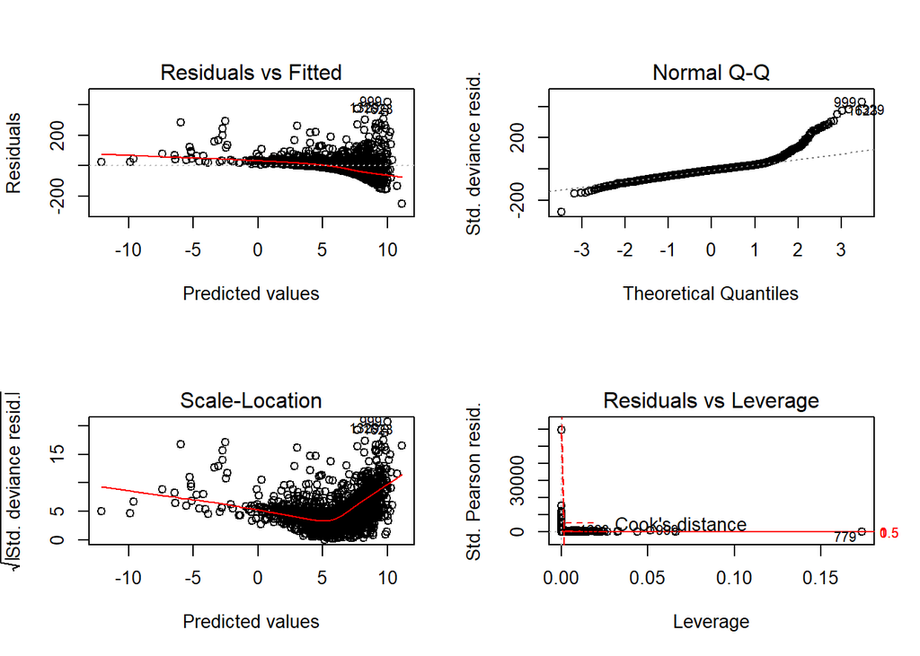

```
## $mfrow
## [1] 1 1
```

```r
# create plots with model examination - cooks distance, residuals distribution, outliers, etc.

# first
print(
par(mfrow=c(2,2)),
plot(first)
)
```

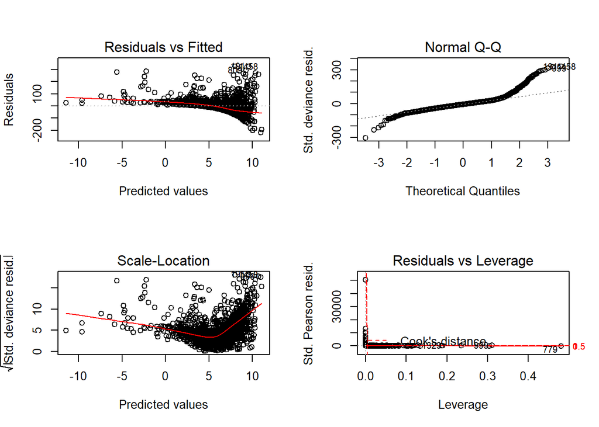

```
## $mfrow
## [1] 2 2
```

```r
# second
print(
par(mfrow=c(2,2)),
plot(second)
)
```

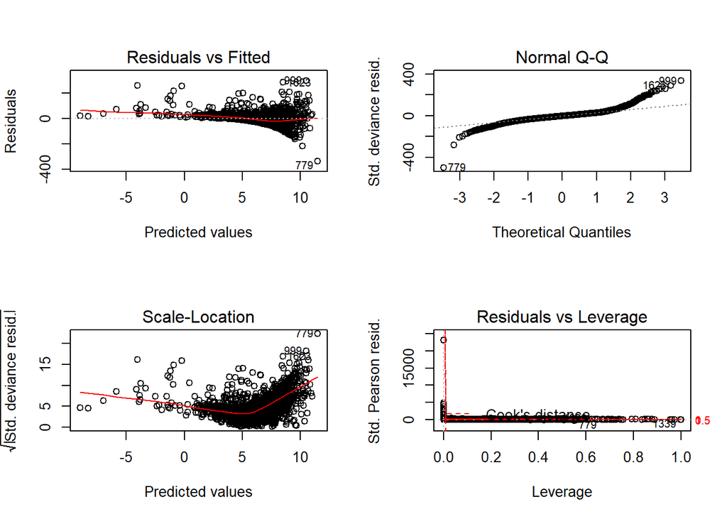

```
## $mfrow
## [1] 2 2
```

```r
# third
print(
par(mfrow=c(2,2)),
plot(third)
)
```

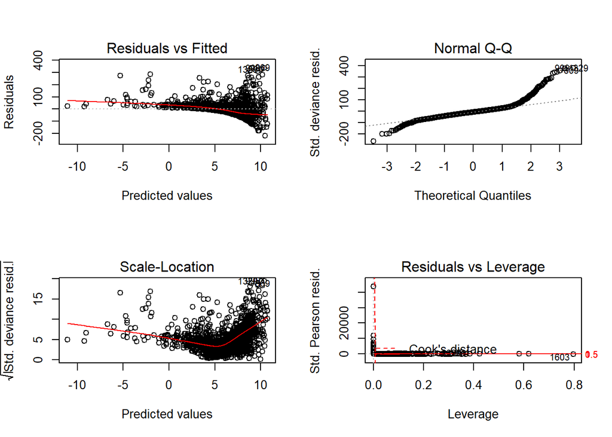

```
## $mfrow
## [1] 2 2
```

```r
# fourth

print(
par(mfrow=c(2,2)),
plot(fourth)
)
```

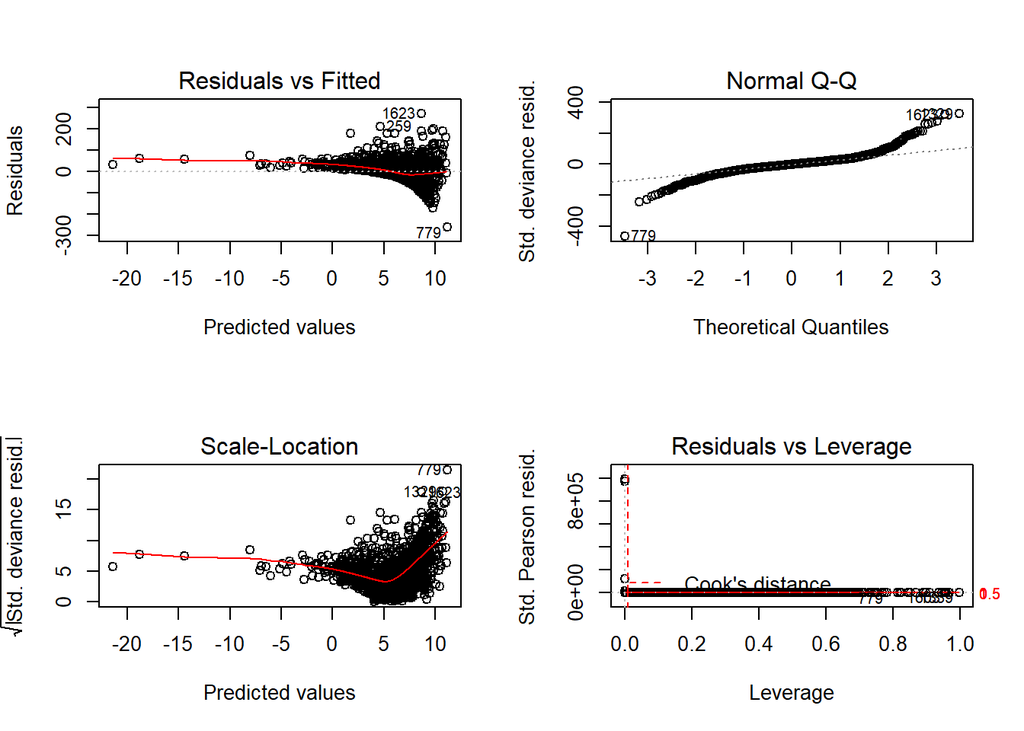

```
## $mfrow
## [1] 2 2
```

```r
# fifth
print(
par(mfrow=c(2,2)),
plot(fifth)
)
```

### Predictive check

```r
# create a function that generate actual distribution and posterior distribution along with sample distributions, to check the prediction uncertainty
# copyright @darribas

generate_draw_poi <- function(m){
  # Set up predictors matrix
  x <- model.matrix(m)
  # Obtain draws of parameters (inferential uncertainty)
  sim_bs <- sim(m, 1)
  # Predicted value
  xb <- x %*% sim_bs@coef[1, ]
  #xb <- x %*% m$coefficients
  # Transform using the link function
  mu <- exp(xb)
  # Obtain a random realization
  y_hat <- rpois(n=length(mu), lambda=mu)
  return(y_hat)
}
```

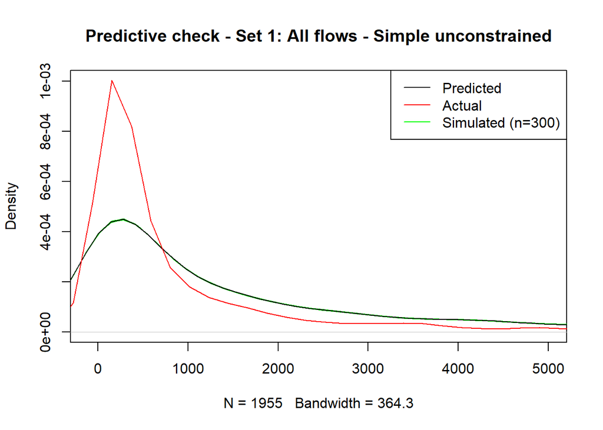

```r
# Call plots with density lines
# predictive check for model 1 - unconstrained for all flows
plot(density(first$fitted.values),
     xlim=c(-100, 5000),
     ylim=c(0, max(c(
                  max(density(first$fitted.values)$y),
                  max(density(GFL$Items)$y)
                  )
               )
      ),
     col='white',
     main='')
# Loop for realizations
for(i in 1:300){
  tmp_y <- generate_draw_poi(first)
  lines(density(tmp_y),
        col='green',
        lwd=0.5
        )
}
lines(density(first$fitted.values),
      col='black',
      main='')
lines(density(GFL$Items),
      col='red',
      main='')
legend('topright',
       c('Predicted', 'Actual', 'Simulated (n=300)'),
       col=c('black', 'red', 'green'),
       lwd=1)
title(main="Predictive check - Set 1: All flows - Simple unconstrained")
```

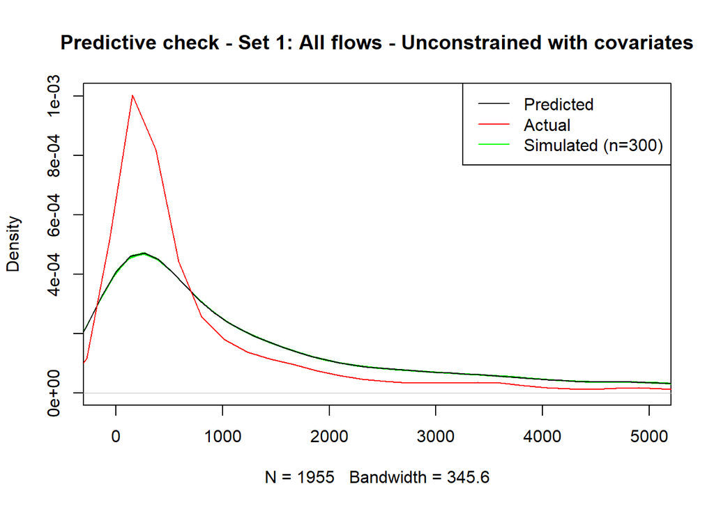

```r
# predictive check for model 2 - unconstrained with covariates for all flows
plot(density(second$fitted.values),
     xlim=c(-100, 5000),
     ylim=c(0, max(c(
                  max(density(second$fitted.values)$y),
                  max(density(GFL$Items)$y)
                  )
               )
      ),
     col='white',
     main='')
# Loop for realizations
for(i in 1:300){
  tmp_y <- generate_draw_poi(second)
  lines(density(tmp_y),
        col='green',
        lwd=0.5
        )
}
lines(density(second$fitted.values),
      col='black',
      main='')
lines(density(GFL$Items),
      col='red',
      main='')
legend('topright',
       c('Predicted', 'Actual', 'Simulated (n=300)'),
       col=c('black', 'red', 'green'),
       lwd=1)
title(main="Predictive check - Set 1: All flows - Unconstrained with covariates")
```

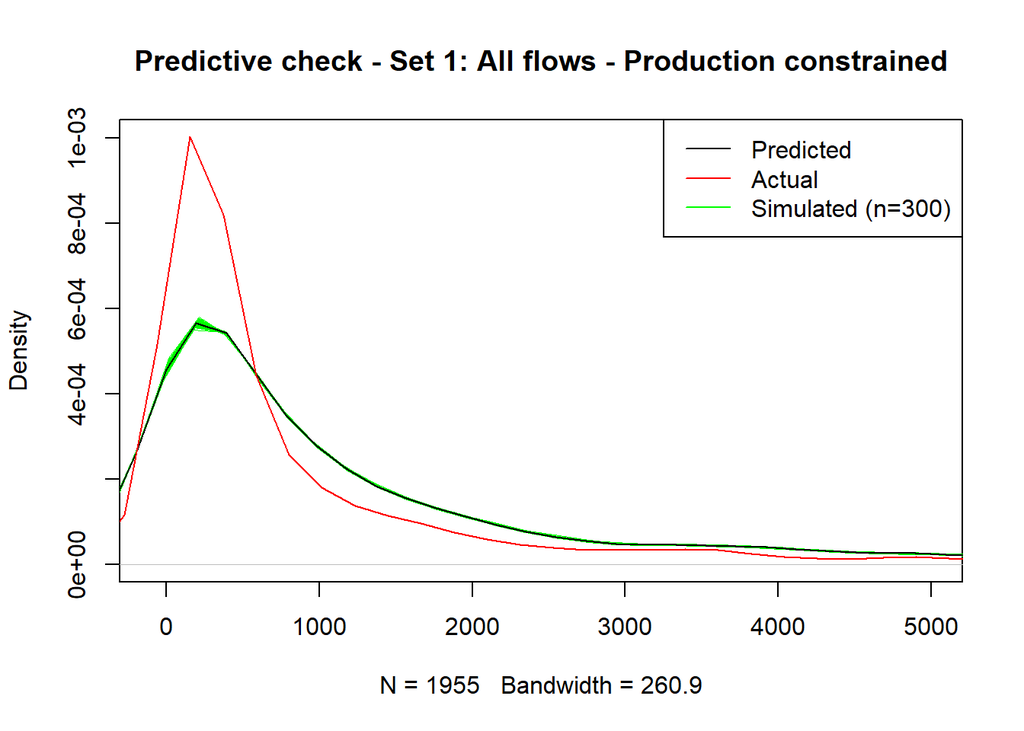

```r
# predictive check for model 3 - production constrained for all flows
plot(density(third$fitted.values),
     xlim=c(-100, 5000),
     ylim=c(0, max(c(
                  max(density(third$fitted.values)$y),
                  max(density(GFL$Items)$y)
                  )
               )
      ),
     col='white',
     main='')
# Loop for realizations
for(i in 1:300){
  tmp_y <- generate_draw_poi(third)
  lines(density(tmp_y),
        col='green',
        lwd=0.5
        )
}
lines(density(third$fitted.values),
      col='black',
      main='')
lines(density(GFL$Items),
      col='red',
      main='')
legend('topright',
       c('Predicted', 'Actual', 'Simulated (n=300)'),
       col=c('black', 'red', 'green'),
       lwd=1)
title(main="Predictive check - Set 1: All flows - Production constrained")
```

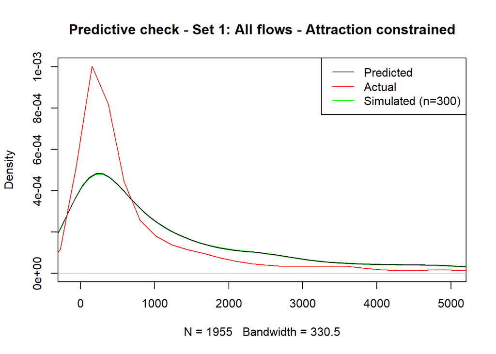

```r
# predictive check for model 4 - attraction constrained for all flows
plot(density(fourth$fitted.values),
     xlim=c(-100, 5000),
     ylim=c(0, max(c(
                  max(density(fourth$fitted.values)$y),
                  max(density(GFL$Items)$y)
                  )
               )
      ),
     col='white',
     main='')
# Loop for realizations
for(i in 1:300){
  tmp_y <- generate_draw_poi(fourth)
  lines(density(tmp_y),
        col='green',
        lwd=0.5
        )
}
lines(density(fourth$fitted.values),
      col='black',
      main='')
lines(density(GFL$Items),
      col='red',
      main='')
legend('topright',
       c('Predicted', 'Actual', 'Simulated (n=300)'),
       col=c('black', 'red', 'green'),
       lwd=1)
title(main="Predictive check - Set 1: All flows - Attraction constrained")
```

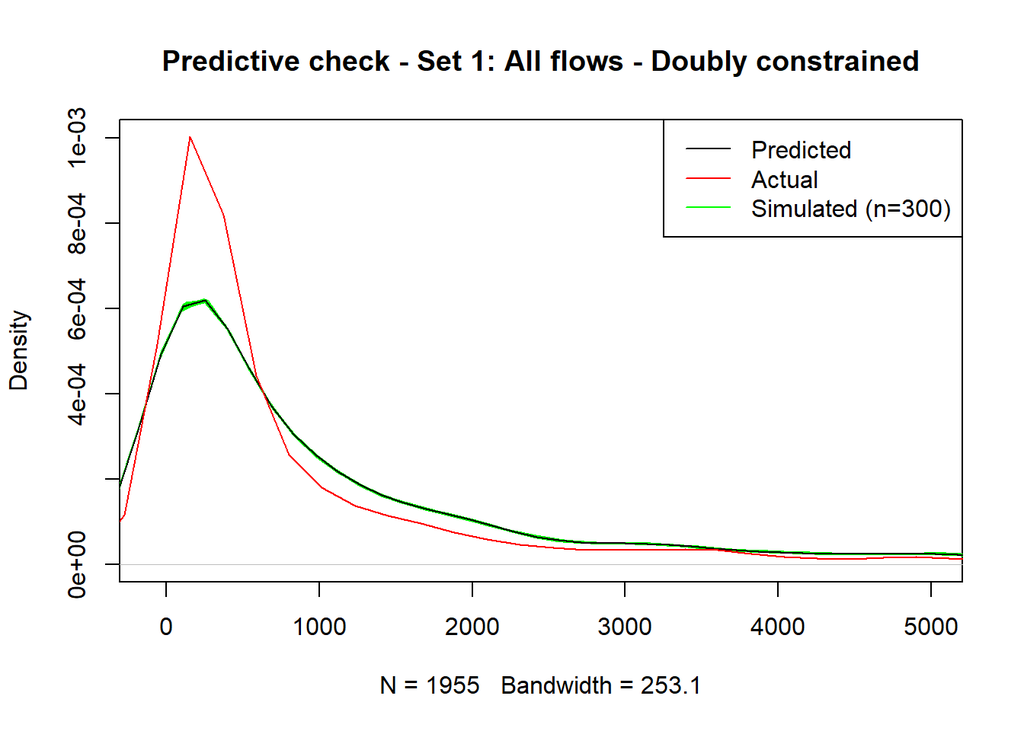

```r
# predictive check for model 5 - doubly constrained for all flows
plot(density(fifth$fitted.values),
     xlim=c(-100, 5000),
     ylim=c(0, max(c(
                  max(density(fifth$fitted.values)$y),
                  max(density(GFL$Items)$y)
                  )
               )
      ),
     col='white',
     main='')
# Loop for realizations
for(i in 1:300){
  tmp_y <- generate_draw_poi(fifth)
  lines(density(tmp_y),
        col='green',
        lwd=0.5
        )
}
lines(density(fifth$fitted.values),
      col='black',
      main='')
lines(density(GFL$Items),
      col='red',
      main='')
legend('topright',
       c('Predicted', 'Actual', 'Simulated (n=300)'),
       col=c('black', 'red', 'green'),
       lwd=1)
title(main="Predictive check - Set 1: All flows - Doubly constrained")
```

### Building matrix for understanding flows

```r
# matrix using all flow data
cdatasubmat6 <- dcast(GFL@data, GP_ODS ~ Ph_ODS, sum, value.var = "Items", margins=c("GP_ODS", "Ph_ODS"))
head(cdatasubmat6)
```

```
##   GP_ODS FA731 FAN25 FAQ22 FC368 FC972 FCT19 FD635 FDV38 FEN99 FEV79 FF015
## 1 N82001     0     0     0     0     0     0     0     0     0     0     0
## 2 N82002     0     0     0     0     0     0     0     0     0   197   270
## 3 N82003     0   231   408     0     0     0     0     0     0     0   136
## 4 N82004     0     0     0     0     0     0     0     0     0     0     0
## 5 N82009     0     0     0     0     0     0     0     0     0     0   791
## 6 N82011     0     0     0     0     0     0     0     0     0   793  1360
##   FF360 FF769 FF987 FFM98 FG049 FGN97 FGX53 FH645 FH796 FHK81 FHM91 FJJ30
## 1     0     0   145     0     0     0   421     0     0     0     0     0
## 2     0     0     0    89     0     0   662     0     0     0     0     0
## 3     0   149     0    71     0     0  2513     0     0     0     0     0
## 4     0     0    45     0     0     0     0     0     0     0     0     0
## 5     0     0 20132   223     0     0   264   189     0     0     0     0
## 6     0   763     0   281     0     0  1527     0     0     0     0     0
##   FJV69 FJV77 FK182 FK207 FK272 FKM99 FL048 FL617 FLM92 FLP52 FLV18 FM249
```

[output cut: 27 more lines]

```r
# matrix that uses double constrained model of all flows
GFL$fifthFitted <- round(fitted(fifth),0)
mat6 <- dcast(GFL@data, GP_ODS ~ Ph_ODS, sum, value.var = "fifthFitted", margins=c("GP_ODS", "Ph_ODS"))
head(mat6)
```

```
##   GP_ODS FA731 FAN25 FAQ22 FC368 FC972 FCT19 FD635 FDV38 FEN99 FEV79 FF015
## 1 N82001     0     0     0     0     0     0     0     0     0     0     0
## 2 N82002     0     0     0     0     0     0     0     0     0    64     9
## 3 N82003     0   514   551     0     0     0     0     0     0     0    18
## 4 N82004     0     0     0     0     0     0     0     0     0     0     0
## 5 N82009     0     0     0     0     0     0     0     0     0     0   168
## 6 N82011     0     0     0     0     0     0     0     0     0   640   688
##   FF360 FF769 FF987 FFM98 FG049 FGN97 FGX53 FH645 FH796 FHK81 FHM91 FJJ30
## 1     0     0    97     0     0     0   315     0     0     0     0     0
## 2     0     0     0     2     0     0  1487     0     0     0     0     0
## 3     0    62     0     3     0     0  2779     0     0     0     0     0
## 4     0     0   265     0     0     0     0     0     0     0     0     0
## 5     0     0 13014    35     0     0   637  1597     0     0     0     0
## 6     0  1304     0   145     0     0   178     0     0     0     0     0
##   FJV69 FJV77 FK182 FK207 FK272 FKM99 FL048 FL617 FLM92 FLP52 FLV18 FM249
```

[output cut: 27 more lines]

## Modelling the highest flows

```r
# select just the first 500 rows of the flow data
GFH <- GFL[1:500, ]
```

```r
# run the models

# 7 - Unconstrained model
selfirst <- glm(Items ~ log(GP_Items_PY) + log(BO_I_PY) + distance , na.action = na.exclude, family = poisson(link = "log"), data = GFH)

# 8 - Unconstrained model with covariates
selsecond <- glm(Items ~ log(GP_Items_PY) + log(BO_I_PY) + distance + dist_centre + GP_Flag +  GP_Partners + GP_pop_tot + GP_eth_prop + BO_day_pop + BO_Format + BO_py_boots_comp + BO_NHS_Desc + BO_py_competitors , na.action = na.exclude, family = poisson(link = "log"), data = GFH)

# 9 - Production constrained model
selthird <- glm(Items ~ GP_ODS  + log(BO_I_PY) +  distance
               , na.action = na.exclude, family = poisson(link = "log"), data = GFH)

# 10 - Attraction constrained model
selfourth <- glm(Items ~ Ph_ODS +log(GP_Items_PY)  +  distance
                , na.action = na.exclude, family = poisson(link = "log"), data = GFH)

# 11 - Doubly constrained model
selfifth <- glm(Items ~  GP_ODS + Ph_ODS + distance
              , na.action = na.exclude, family = poisson(link = "log"), data = GFH)

# 12 - Mixed effect model
# selrandom <- glmer(Items ~ GP_ODS + log(BO_I_PY) +  distance + (1|dist_centre) ,  family = poisson(link = "log"), data = GFH@data)
```

```r
# R2, AIC, RMSE
r2s <- data.frame(model=c( 'selfirst', 'selsecond', 'selthird','selfourth', 'selfifth'),
                      R2_logit=c(
                              R2logit(Items, selfirst),
                              R2logit(Items, selsecond),
                             R2logit(Items, selthird),
                             R2logit(Items, selfourth),
                             R2logit(Items, selfifth)))
r2s
```

```
##       model  R2_logit
## 1  selfirst 0.3978508
## 2 selsecond 0.5244070
## 3  selthird 0.7441787
## 4 selfourth 0.5701210
## 5  selfifth 0.8445670
```

```r
AIC(selfirst, selsecond, selthird, selfourth, selfifth)
```

```
##            df       AIC
## selfirst    4 3339706.0
## selsecond  19 2638891.9
## selthird  217 1422233.1
## selfourth  63 2385824.3
## selfifth  273  866413.8
```

```r
rmses <- data.frame(model=c( 'selfirst', 'selsecond', 'selthird','selfourth', 'selfifth'),
                      RMSE=c(
                              rmse(GFH$Items, selfirst$fitted.values),
                              rmse(GFH$Items, selsecond$fitted.values),
                             rmse(GFH$Items, selthird$fitted.values),
                             rmse(GFH$Items, selfourth$fitted.values),
                             rmse(GFH$Items, selfifth$fitted.values)

                           )
                      )
rmses
```

```
##       model      RMSE
## 1  selfirst 10511.273
## 2 selsecond  8685.659
## 3  selthird  7114.174
## 4 selfourth  8414.385
## 5  selfifth  4696.332
```

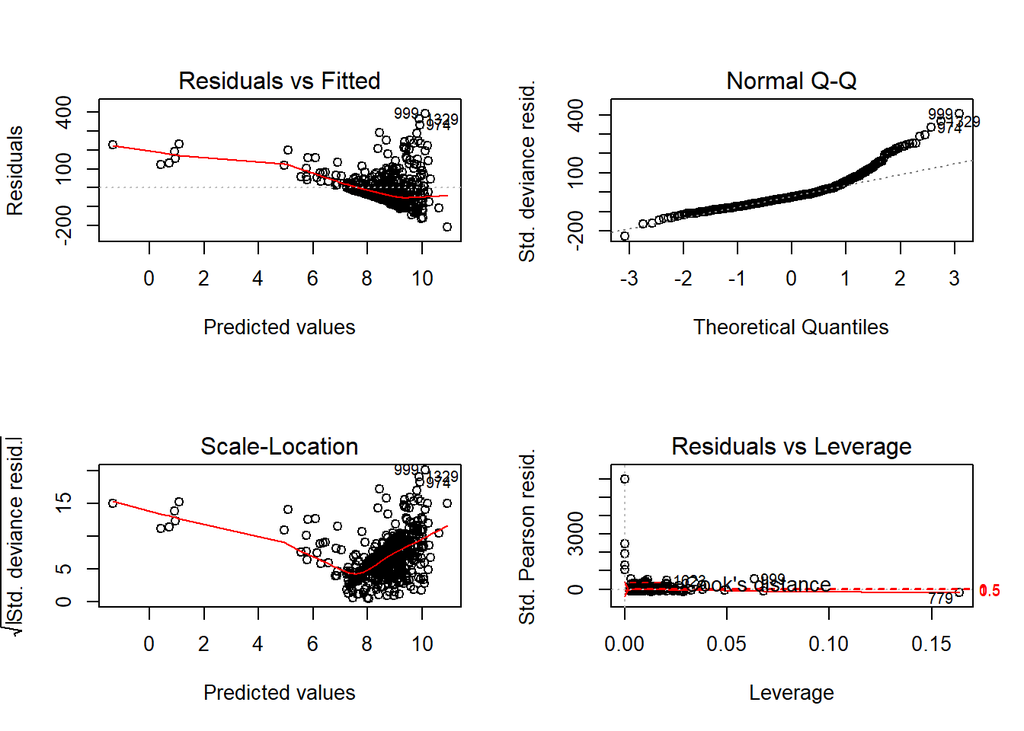

```
## $mfrow
## [1] 1 1
```

```r
# Model diagnostics

# 7 - Unconstrained model
print(
par(mfrow=c(2,2)),
plot(selfirst)
)
```

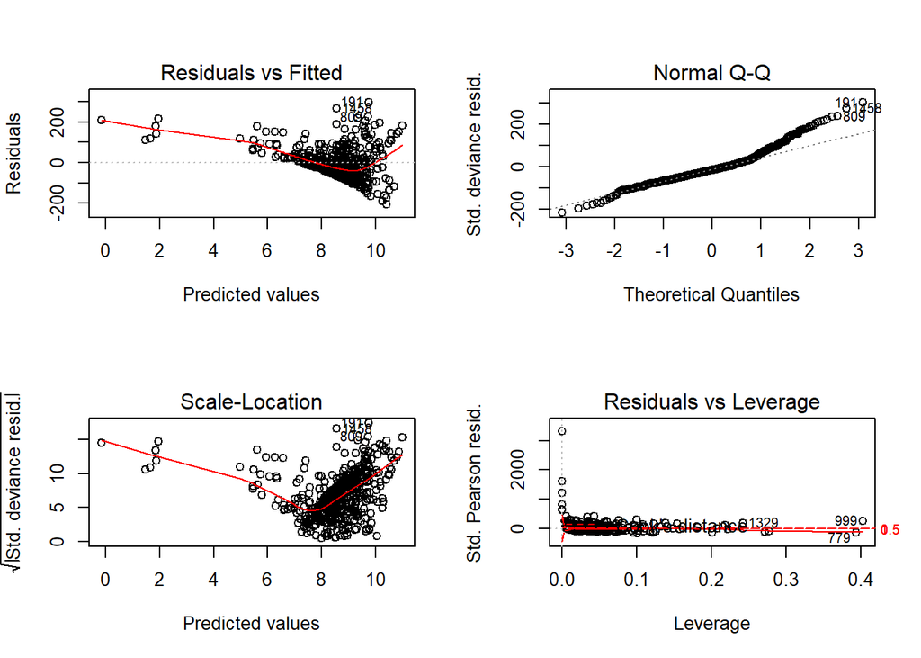

```
## $mfrow
## [1] 2 2
```

```r
# 8 - Unconstrained model with covariates
print(
par(mfrow=c(2,2)),
plot(selsecond)
)
```

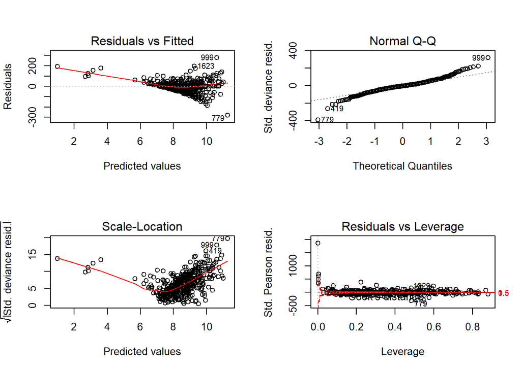

```
## $mfrow
## [1] 2 2
```

```r
# 9 - Production constrained model
print(
par(mfrow=c(2,2)),
plot(selthird)
)
```

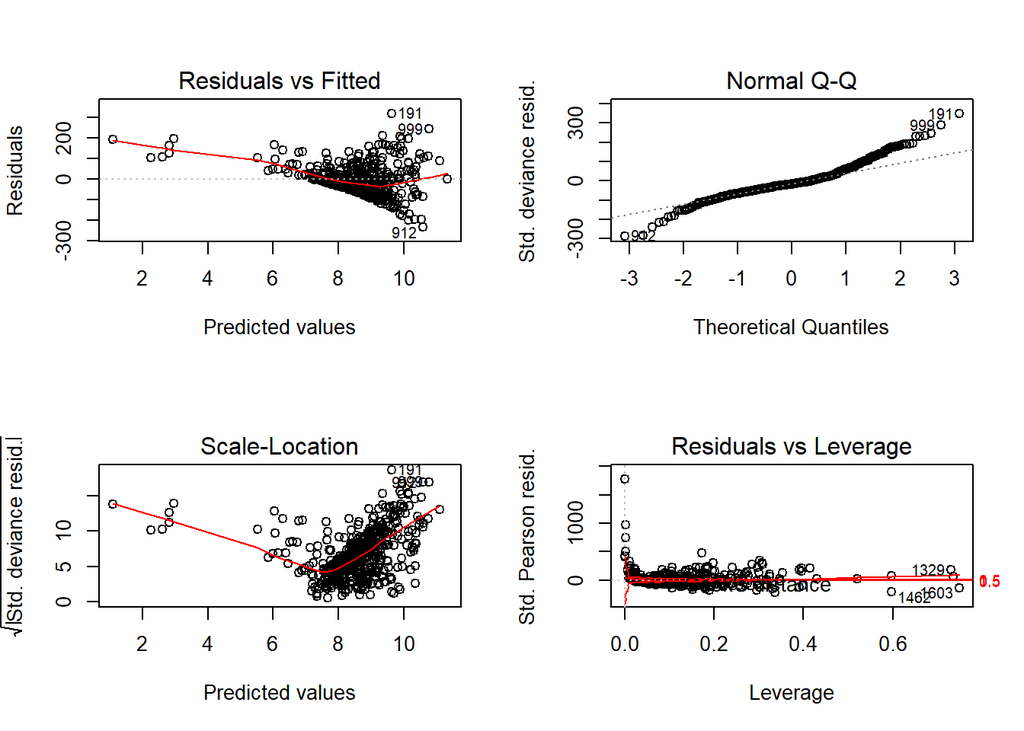

```
## $mfrow
## [1] 2 2
```

```r
# 10 - Attraction constrained model
print(
par(mfrow=c(2,2)),
plot(selfourth)
)
```

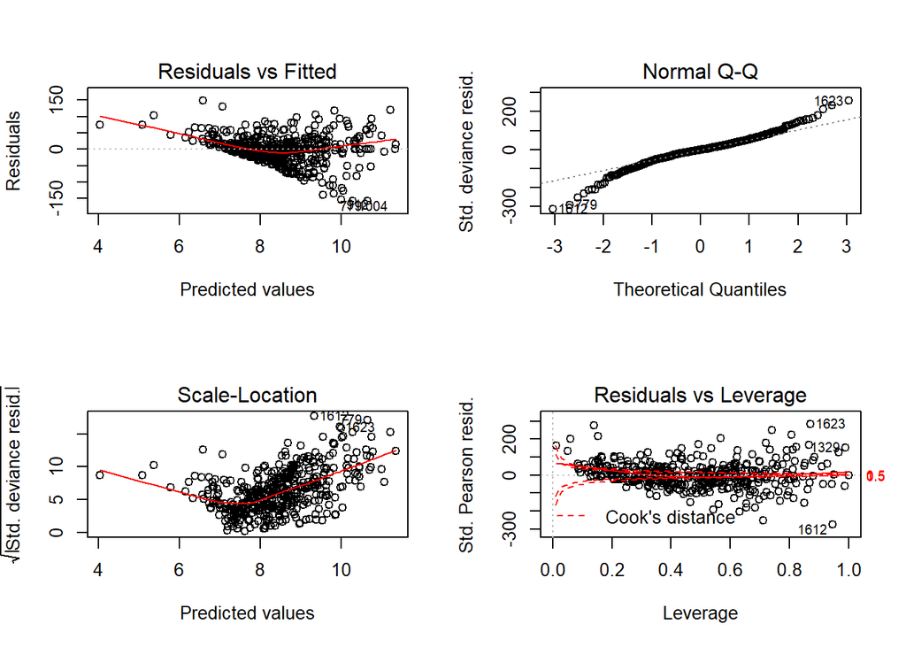

```
## $mfrow
## [1] 2 2
```

```r
# 11 - Doubly constrained model
print(
par(mfrow=c(2,2)),
plot(selfifth)
)
```

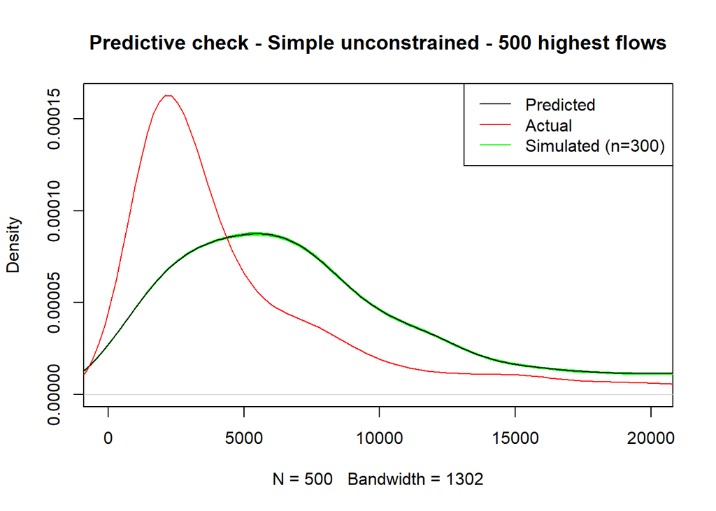

```r
# predictive check

# 7 - Unconstrained model
plot(density(selfirst$fitted.values),
     xlim=c(-100, 20000),
     ylim=c(0, max(c(
                  max(density(selfirst$fitted.values)$y),
                  max(density(GFH$Items)$y)
                  )
               )
      ),
     col='white',
     main='')
# Loop for realizations
for(i in 1:300){
  tmp_y <- generate_draw_poi(selfirst)
  lines(density(tmp_y),
        col='green',
        lwd=0.5
        )
}
lines(density(selfirst$fitted.values),
      col='black',
      main='')
lines(density(GFH$Items),
      col='red',
      main='')
legend('topright',
       c('Predicted', 'Actual', 'Simulated (n=300)'),
       col=c('black', 'red', 'green'),
       lwd=1)
title(main="Predictive check - Simple unconstrained - 500 highest flows")
```

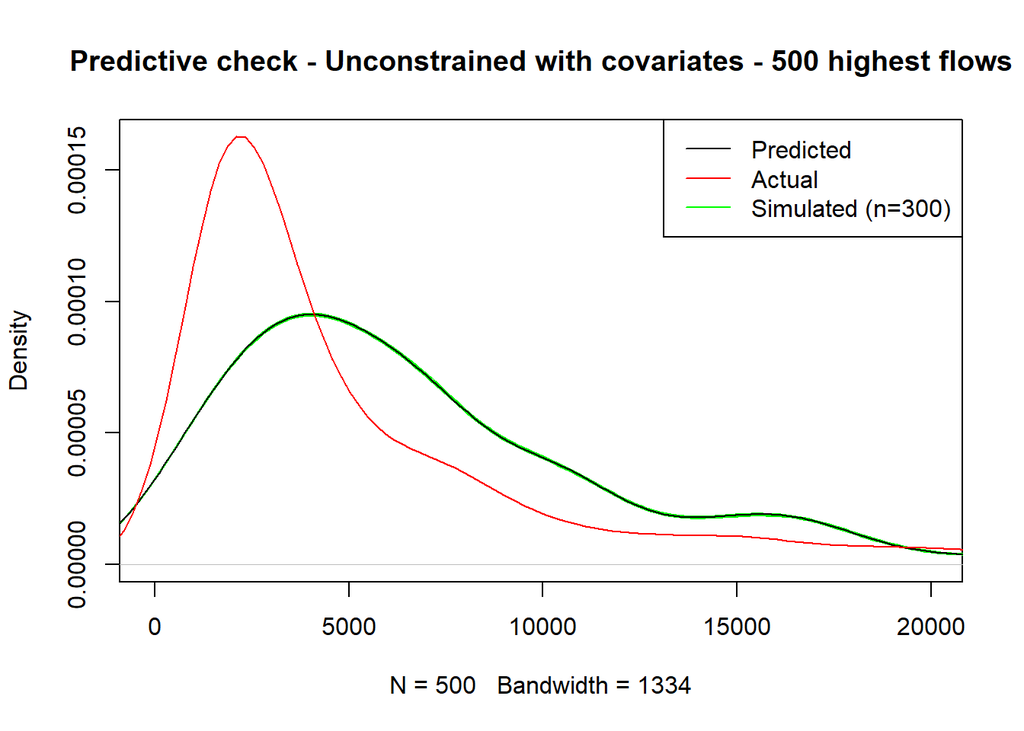

```r
# 8 - Unconstrained model with covariates
plot(density(selsecond$fitted.values),
     xlim=c(-100, 20000),
     ylim=c(0, max(c(
                  max(density(selsecond$fitted.values)$y),
                  max(density(GFH$Items)$y)
                  )
               )
      ),
     col='white',
     main='')
# Loop for realizations
for(i in 1:300){
  tmp_y <- generate_draw_poi(selsecond)
  lines(density(tmp_y),
        col='green',
        lwd=0.5
        )
}
lines(density(selsecond$fitted.values),
      col='black',
      main='')
lines(density(GFH$Items),
      col='red',
      main='')
legend('topright',
       c('Predicted', 'Actual', 'Simulated (n=300)'),
       col=c('black', 'red', 'green'),
       lwd=1)
title(main="Predictive check - Unconstrained with covariates - 500 highest flows")
```

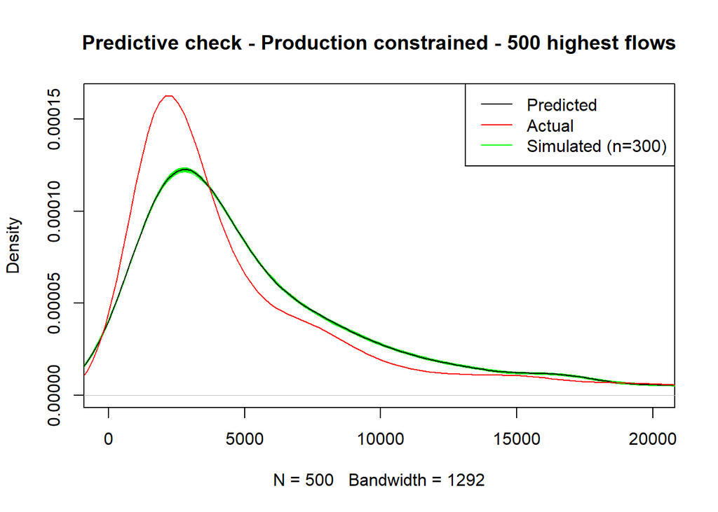

```r
# 9 - Production constrained model
plot(density(selthird$fitted.values),
     xlim=c(-100, 20000),
     ylim=c(0, max(c(
                  max(density(selthird$fitted.values)$y),
                  max(density(GFH$Items)$y)
                  )
               )
      ),
     col='white',
     main='')
# Loop for realizations
for(i in 1:300){
  tmp_y <- generate_draw_poi(selthird)
  lines(density(tmp_y),
        col='green',
        lwd=0.5
        )
}
lines(density(selthird$fitted.values),
      col='black',
      main='')
lines(density(GFH$Items),
      col='red',
      main='')
legend('topright',
       c('Predicted', 'Actual', 'Simulated (n=300)'),
       col=c('black', 'red', 'green'),
       lwd=1)
title(main="Predictive check - Production constrained - 500 highest flows")
```

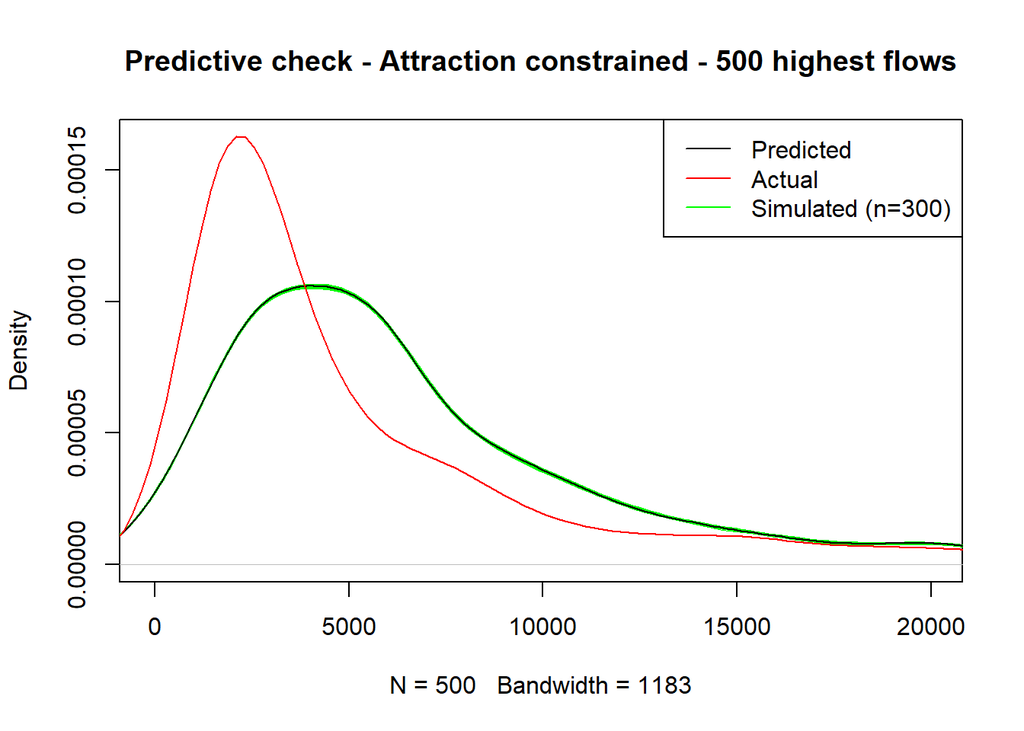

```r
# 10 - Attraction constrained model
plot(density(selfourth$fitted.values),
     xlim=c(-100, 20000),
     ylim=c(0, max(c(
                  max(density(selfourth$fitted.values)$y),
                  max(density(GFH$Items)$y)
                  )
               )
      ),
     col='white',
     main='')
# Loop for realizations
for(i in 1:300){
  tmp_y <- generate_draw_poi(selfourth)
  lines(density(tmp_y),
        col='green',
        lwd=0.5
        )
}
lines(density(selfourth$fitted.values),
      col='black',
      main='')
lines(density(GFH$Items),
      col='red',
      main='')
legend('topright',
       c('Predicted', 'Actual', 'Simulated (n=300)'),
       col=c('black', 'red', 'green'),
       lwd=1)
title(main="Predictive check - Attraction constrained - 500 highest flows")
```

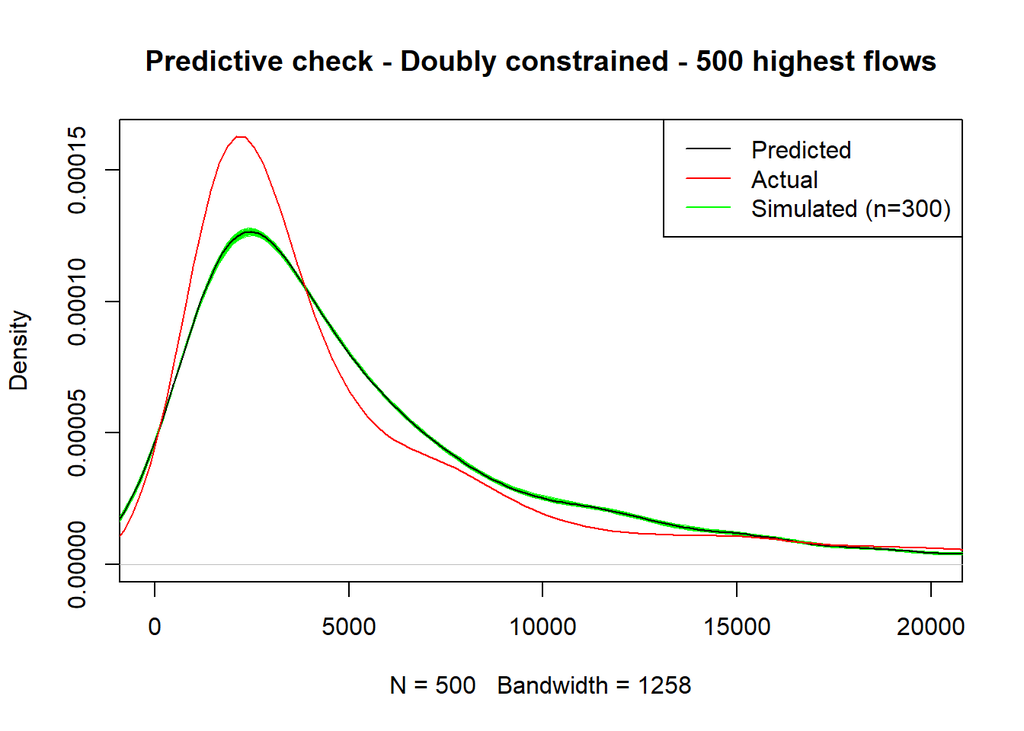

```r
# 11 - Doubly constrained model
plot(density(selfifth$fitted.values),
     xlim=c(-100, 20000),
     ylim=c(0, max(c(
                  max(density(selfifth$fitted.values)$y),
                  max(density(GFH$Items)$y)
                  )
               )
      ),
     col='white',
     main='')
# Loop for realizations
for(i in 1:300){
  tmp_y <- generate_draw_poi(selfifth)
  lines(density(tmp_y),
        col='green',
        lwd=0.5
        )
}
#
lines(density(selfifth$fitted.values),
      col='black',
      main='')
lines(density(GFH$Items),
      col='red',
      main='')
legend('topright',
       c('Predicted', 'Actual', 'Simulated (n=300)'),
       col=c('black', 'red', 'green'),
       lwd=1)
title(main="Predictive check - Doubly constrained - 500 highest flows")
```

## Modelling interegional flows

```r
# selecting just the flows within distance of 800 metres
GFI <- GFL[which(GFL$distance < 800), ]
```

```r
# modelling interregional flows
# 13 - Unconstrained model
intfirst <- glm(Items ~ log(GP_Items_PY) + log(BO_I_PY) + distance , na.action = na.exclude, family = poisson(link = "log"), data = GFI)

# 14 - Unconstrained model with covariates
intsecond <- glm(Items ~ log(GP_Items_PY) + log(BO_I_PY) + distance + dist_centre + GP_Flag +  GP_Partners + GP_pop_tot + GP_eth_prop + BO_day_pop + BO_Format + BO_py_boots_comp + BO_NHS_Desc + BO_py_competitors , na.action = na.exclude, family = poisson(link = "log"), data = GFI)

# 15 - Production constrained model
intthird <- glm(Items ~ GP_ODS  + log(BO_I_PY) +  distance
               , na.action = na.exclude, family = poisson(link = "log"), data = GFI)

# 16 - Attraction constrained model
intfourth <- glm(Items ~ Ph_ODS +log(GP_Items_PY)  +  distance
                , na.action = na.exclude, family = poisson(link = "log"), data = GFI)

# 17 - Doubly constrained model
intfifth <- glm(Items ~  GP_ODS + Ph_ODS + distance
              , na.action = na.exclude, family = poisson(link = "log"), data = GFI)

# 18 - Mixed effect model
# intrandom <- glmer(Items ~ GP_ODS + log(BO_I_PY) +  distance + (1|dist_centre) ,  family = poisson(link = "log"), data = GFI@data)
```

```r
# R2, AIC, RMSE
r2s <- data.frame(model=c( 'intfirst', 'intsecond', 'intthird','intfourth', 'intfifth'),
                      R2_logit=c(
                              R2logit(Items, intfirst),
                              R2logit(Items, intsecond),
                             R2logit(Items, intthird),
                             R2logit(Items, intfourth),
                             R2logit(Items, intfifth)))
r2s
```

```
##       model  R2_logit
## 1  intfirst 0.5660939
## 2 intsecond 0.6979463
## 3  intthird 0.9579104
## 4 intfourth 0.7923404
## 5  intfifth 0.9805615
```

```r
AIC(intfirst, intsecond, intthird, intfourth, intfifth)
```

```
##            df       AIC
## intfirst    4 981151.82
## intsecond  18 683479.94
## intthird  106  96701.73
## intfourth  57 470432.30
## intfifth  120  45587.41
```

```r
rmses <- data.frame(model=c( 'intfirst', 'intsecond', 'intthird','intfourth', 'intfifth'),
                      RMSE=c(
                              rmse(GFI$Items, intfirst$fitted.values),
                              rmse(GFI$Items, intsecond$fitted.values),
                             rmse(GFI$Items, intthird$fitted.values),
                             rmse(GFI$Items, intfourth$fitted.values),
                             rmse(GFI$Items, intfifth$fitted.values)

                           )
                      )
rmses
```

```
##       model      RMSE
## 1  intfirst 12783.353
## 2 intsecond 10367.775
## 3  intthird  3392.608
## 4 intfourth  8043.891
## 5  intfifth  2183.107
```

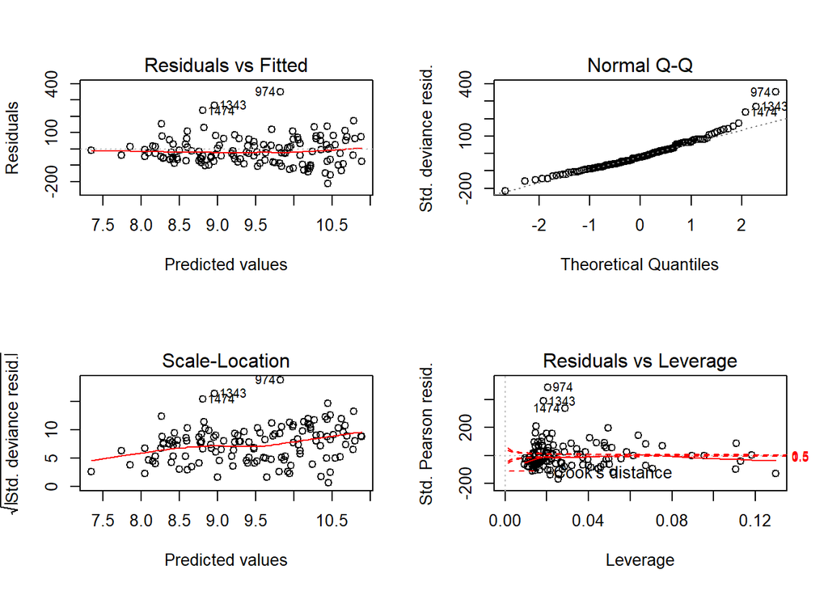

```
## $mfrow
## [1] 1 1
```

```r
# model diagnostics
# 13 - Unconstrained model
print(
par(mfrow=c(2,2)),
plot(intfirst)
)
```

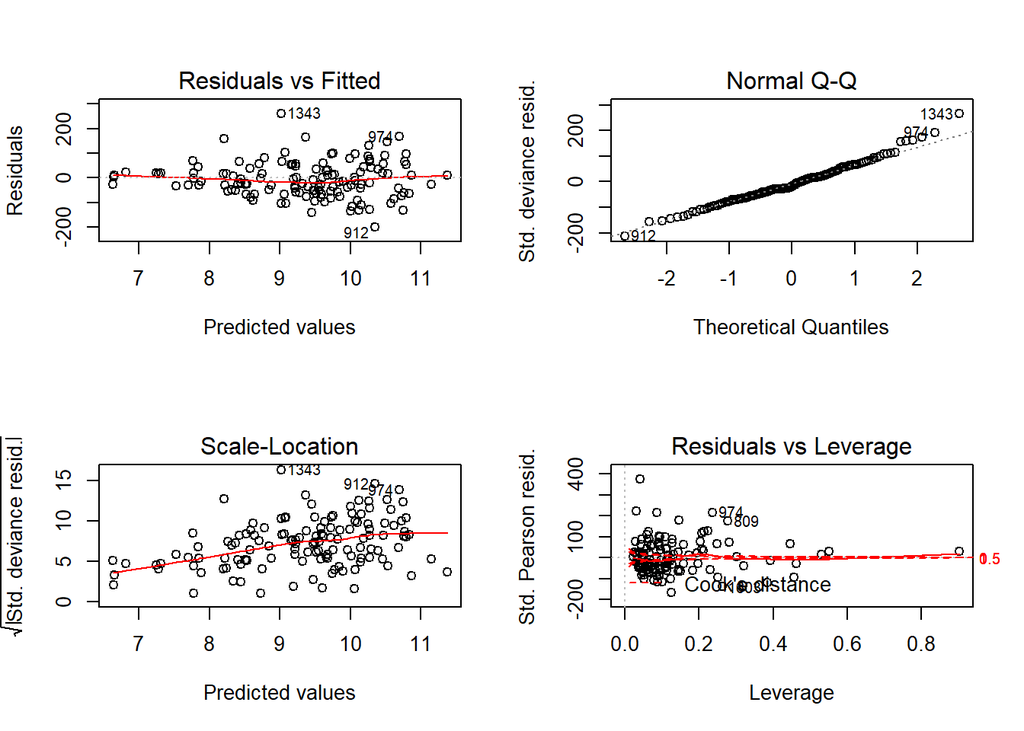

```
## $mfrow
## [1] 2 2
```

```r
# 14 - Unconstrained model with covariates
print(
par(mfrow=c(2,2)),
plot(intsecond)
)
```

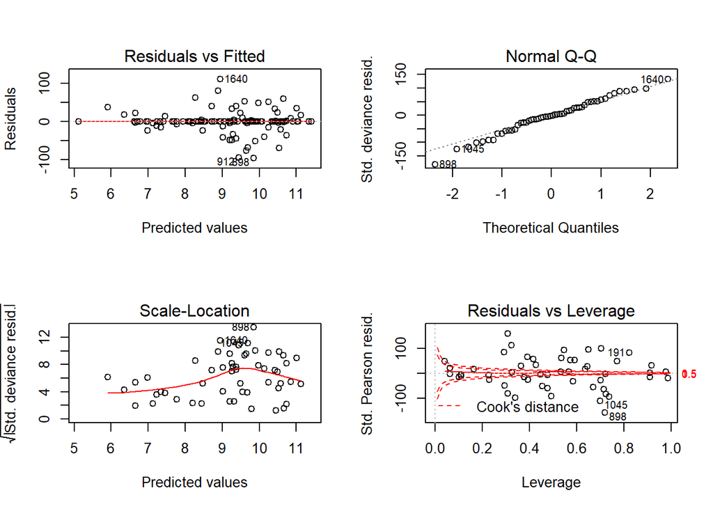

```
## $mfrow
## [1] 2 2
```

```r
# 15 - Production constrained model
print(
par(mfrow=c(2,2)),
plot(intthird)
)
```

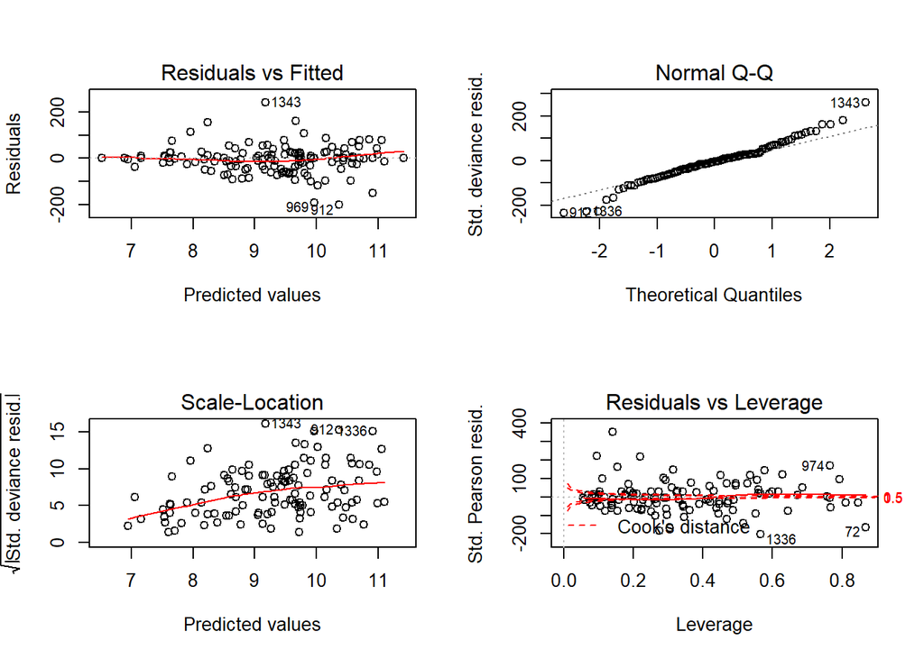

```
## $mfrow
## [1] 2 2
```

```r
# 16 - Attraction constrained model
print(
par(mfrow=c(2,2)),
plot(intfourth)
)
```

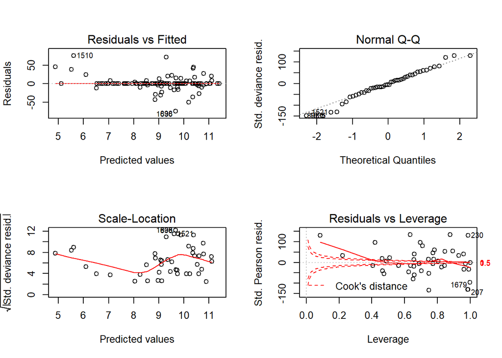

```
## $mfrow
## [1] 2 2
```

```r
# 17 - Doubly constrained model
print(
par(mfrow=c(2,2)),
plot(intfifth)
)
```

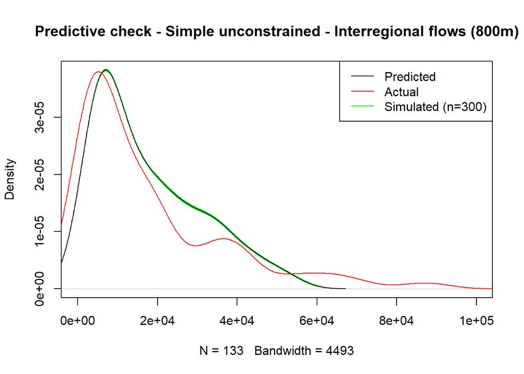

```r
# Predictive check
# 13 - Unconstrained model
plot(density(intfirst$fitted.values),
     xlim=c(-100, 100000),
     ylim=c(0, max(c(
                  max(density(intfirst$fitted.values)$y),
                  max(density(GFI$Items)$y)
                  )
               )
      ),
     col='white',
     main='')
# Loop for realizations
for(i in 1:300){
  tmp_y <- generate_draw_poi(intfirst)
  lines(density(tmp_y),
        col='green',
        lwd=0.5
        )
}
lines(density(intfirst$fitted.values),
      col='black',
      main='')
lines(density(GFI$Items),
      col='red',
      main='')
legend('topright',
       c('Predicted', 'Actual', 'Simulated (n=300)'),
       col=c('black', 'red', 'green'),
       lwd=1)
title(main="Predictive check - Simple unconstrained - Interregional flows (800m)")
```

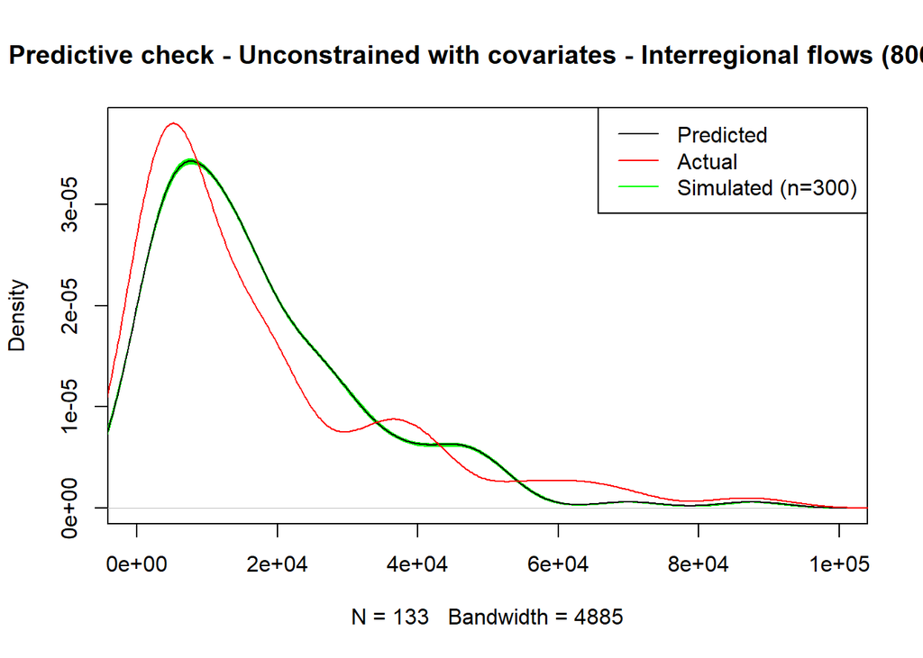

```r
# 14 - Unconstrained model with covariates
plot(density(intsecond$fitted.values),
     xlim=c(-100, 100000),
     ylim=c(0, max(c(
                  max(density(intsecond$fitted.values)$y),
                  max(density(GFI$Items)$y)
                  )
               )
      ),
     col='white',
     main='')
# Loop for realizations
for(i in 1:300){
  tmp_y <- generate_draw_poi(intsecond)
  lines(density(tmp_y),
        col='green',
        lwd=0.5
        )
}
#
lines(density(intsecond$fitted.values),
      col='black',
      main='')
lines(density(GFI$Items),
      col='red',
      main='')
legend('topright',
       c('Predicted', 'Actual', 'Simulated (n=300)'),
       col=c('black', 'red', 'green'),
       lwd=1)
title(main="Predictive check - Unconstrained with covariates - Interregional flows (800m)")
```

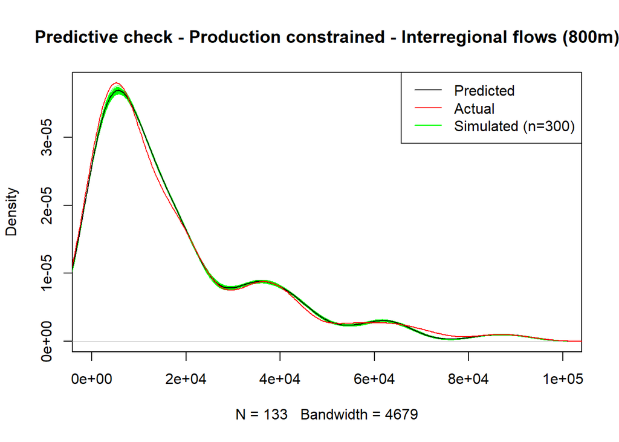

```r
# 15 - Production constrained model
plot(density(intthird$fitted.values),
     xlim=c(-100, 100000),
     ylim=c(0, max(c(
                  max(density(intthird$fitted.values)$y),
                  max(density(GFI$Items)$y)
                  )
               )
      ),
     col='white',
     main='')
# Loop for realizations
for(i in 1:300){
  tmp_y <- generate_draw_poi(intthird)
  lines(density(tmp_y),
        col='green',
        lwd=0.5
        )
}
lines(density(intthird$fitted.values),
      col='black',
      main='')
lines(density(GFI$Items),
      col='red',
      main='')
legend('topright',
       c('Predicted', 'Actual', 'Simulated (n=300)'),
       col=c('black', 'red', 'green'),
       lwd=1)
title(main="Predictive check - Production constrained - Interregional flows (800m)")
```

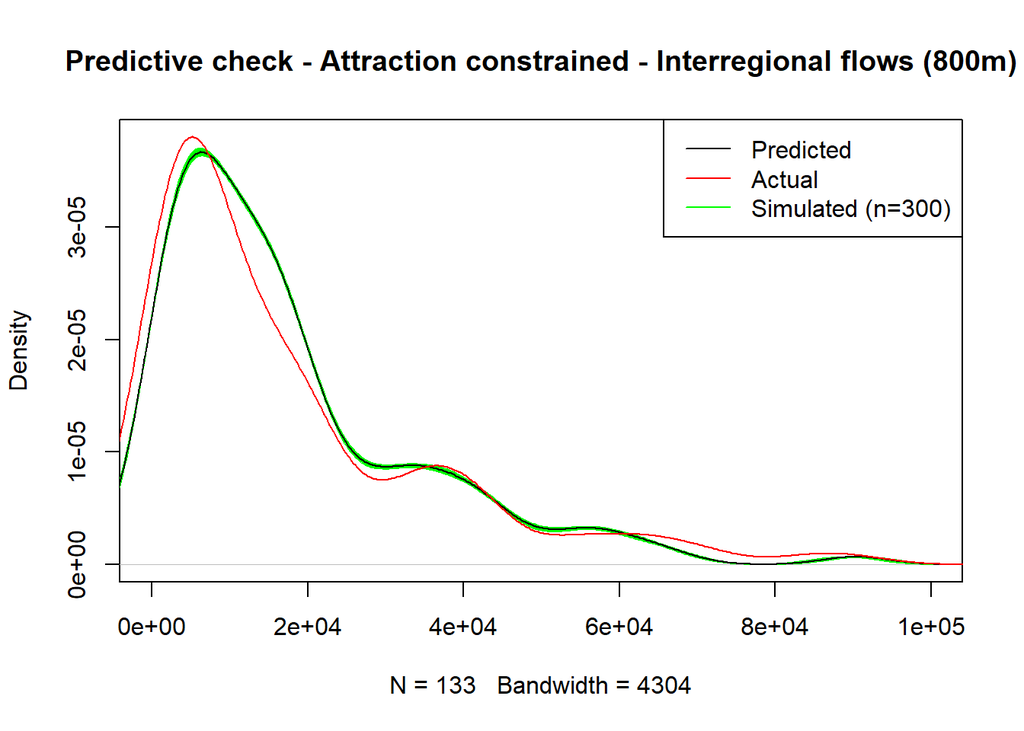

```r
# 16 - Attraction constrained model
plot(density(intfourth$fitted.values),
     xlim=c(-100, 100000),
     ylim=c(0, max(c(
                  max(density(intfourth$fitted.values)$y),
                  max(density(GFI$Items)$y)
                  )
               )
      ),
     col='white',
     main='')
# Loop for realizations
for(i in 1:300){
  tmp_y <- generate_draw_poi(intfourth)
  lines(density(tmp_y),
        col='green',
        lwd=0.5
        )
}
lines(density(intfourth$fitted.values),
      col='black',
      main='')
lines(density(GFI$Items),
      col='red',
      main='')
legend('topright',
       c('Predicted', 'Actual', 'Simulated (n=300)'),
       col=c('black', 'red', 'green'),
       lwd=1)
title(main="Predictive check - Attraction constrained - Interregional flows (800m)")
```

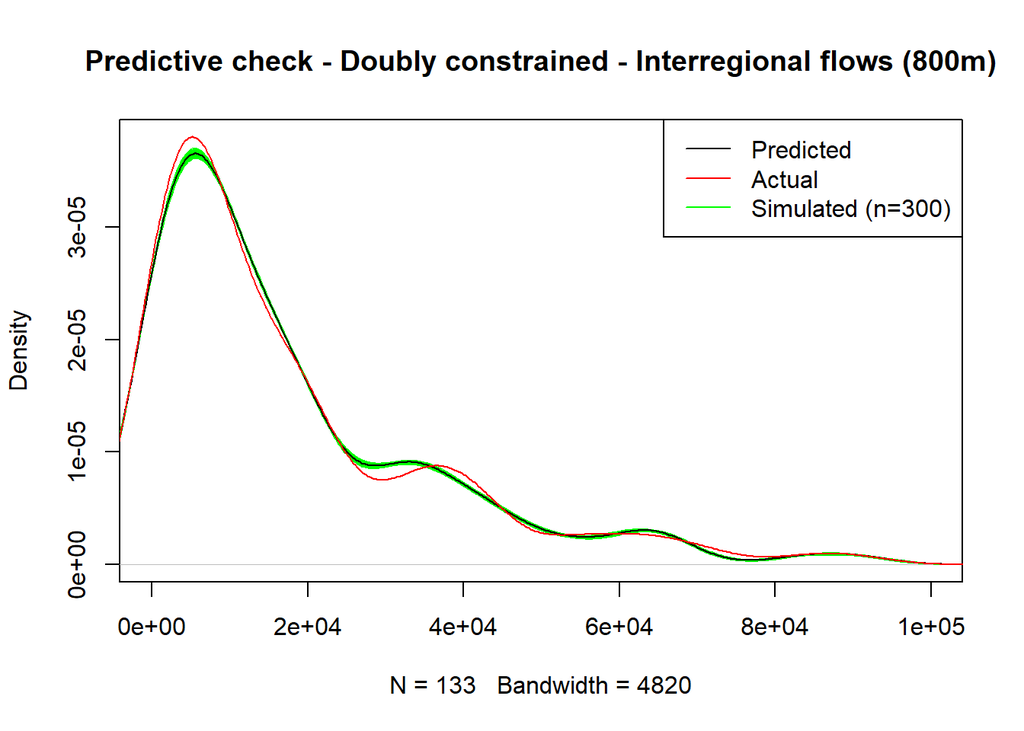

```r
# 17 - Doubly constrained model
plot(density(intfifth$fitted.values),
     xlim=c(-100, 100000),
     ylim=c(0, max(c(
                  max(density(intfifth$fitted.values)$y),
                  max(density(GFI$Items)$y)
                  )
               )
      ),
     col='white',
     main='')
# Loop for realizations
for(i in 1:300){
  tmp_y <- generate_draw_poi(intfifth)
  lines(density(tmp_y),
        col='green',
        lwd=0.5
        )
}
lines(density(intfifth$fitted.values),
      col='black',
      main='')
lines(density(GFI$Items),
      col='red',
      main='')
legend('topright',
       c('Predicted', 'Actual', 'Simulated (n=300)'),
       col=c('black', 'red', 'green'),
       lwd=1)
title(main="Predictive check - Doubly constrained - Interregional flows (800m)")
```